# Harmonizing cartographic language data

Niko Partanen

1/22/2018

## Notes

- All data used shared by CC-BY
  - [SKN, Samples of Spoken Finnish](http://metashare.csc.fi/repository/browse/samples-of-spoken-finnish/642b58defccc11e18b49005056be118e3444ea5bb1dd46a5a4ca4829e93da406/)
  - [Murreaineistot](https://avaa.tdata.fi/web/kotus/aineistot) by KOTUS
- Some credits missing, some code copy-pasted from lingtypology
- I have got my version through [Korp](https://korp.csc.fi/#?corpus=skn) API (is obviously allowed, not maybe recommended)

## Data harmonization and linguistic mapping

At least three data types:

- Typological data (lingtypology!)
- Dialect atlas data
- Corpus data

## Typology

```r
library(lingtypology)
library(tidyverse)
```

```r
library(leaflet)
library(leaflet.minicharts)
library(sf)
library(glue)
uralic <- lingtypology::lang.aff("Uralic")
wals_85A <- wals.feature("85A")
wals_85A_scandinavia <- wals_85A %>% filter(language %in% c("Finnish", "Russian", "Swedish"))

map.feature(languages = wals_85A_scandinavia$language,
              features = wals_85A_scandinavia$`85A`,
              label = wals_85A_scandinavia$language,
              shape = c("➡", "⬅"))
```

[interactive chart not shown]

## Extends to linguistic area maps

[interactive chart not shown]

[figure not shown]

```r
map.feature(languages = circassian$language,
            features = circassian$dialect,
            label = circassian$village,
            latitude = circassian$latitude,
            longitude = circassian$longitude)
```

```r
kpv <- read_csv("https://raw.githubusercontent.com/langdoc/kpv-geography/master/kpv.csv")
map.feature(languages = kpv$language,
            features = kpv$dialect,
            label = kpv$village,
            latitude = kpv$latitude,
            longitude = kpv$longitude)
```

[interactive chart not shown]

## Comments

- Should the `village` be changed to `name` and `settlement_type`, or some equivalents?
  - People live in cities (basically anywhere)
  - We want to maintain only one database of place info
- How we make sure these identifiers connect to other databases?
  - Is this realistic to start with?

## Dialect atlas

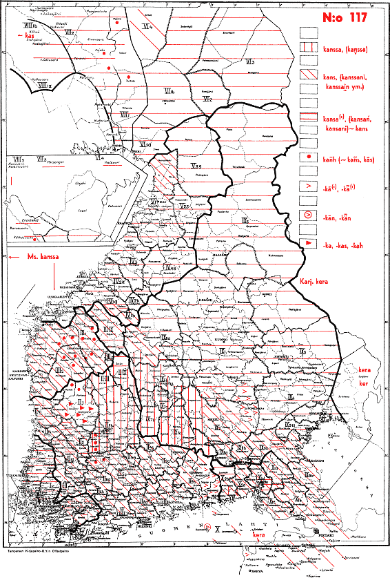

Map source: http://kettunen.fnhost.org/html/kett117.html

```r
sfc_as_cols <- function(x, names = c("longitude","latitude")) {
  stopifnot(inherits(x,"sf") && inherits(sf::st_geometry(x),"sfc_POINT"))
  ret <- sf::st_coordinates(x)
  ret <- tibble::as_tibble(ret)
  stopifnot(length(names) == ncol(ret))
  x <- x[ , !names(x) %in% names]
  ret <- setNames(ret,names)
  dplyr::bind_cols(x,ret)
}

kettunen <- st_read('data/kettunen.shp') %>% st_transform("+proj=longlat +datum=WGS84") %>% sfc_as_cols()
```

```r
map_finnic <- function(data, map =  "Kartta 151"){

        my_colors <-
          c(
            "#1f77b4",
            "#ff7f0e",
            "#2ca02c",
            "#d62728",
            "#9467bd",
            "#8c564b",
            "#e377c2",
            "#7f7f7f",
            "#17becf",
            sample(grDevices::colors()[!grepl("ivory|azure|white|gray|grey|black|pink|1",
                                              grDevices::colors())])
          )
          corpus <- data
          current_selection <- corpus %>% filter(map_id == map)
          pal <- colorFactor({my_colors[1:length(unique(current_selection$feature_value))]},
                                      domain = current_selection$feature_value)

          title_text <- current_selection$feature_description[1] %>% as.character()

          leaflet(data = current_selection) %>%
            addTiles() %>%
            addCircleMarkers(color = ~pal(feature_value),
                             radius = 4,
                             stroke = FALSE, fillOpacity = 0.5,
                             popup = ~feature_value) %>%
            addLegend("bottomleft", pal = pal, values = ~feature_value,
                      title = title_text,
                      opacity = 1
            )

}

kettunen_names <- names(kettunen)

kettunen <- kettunen %>% mutate(ilmio = as.character(ilmio)) %>%
  rename(feature_id = ilmio_id,
                    feature_value = ilmio,
                    feature_description = kuvaus,
                    location = paikka_nim) %>%
  mutate(map_id = str_extract(alaryhma_n, "^[^:]+(?=:)"))

map_finnic(kettunen, "Kartta 117")
```

[interactive chart not shown]

## Data for these maps

Features used in my variants of Finnic dialect maps:

```r
names(kettunen_names)
```

[output not shown]

## Using dialect corpus

```r
skn <- read_rds("data/skn_df.rds") %>%
  left_join(read_csv("data/skn_paikat.csv"))
skn_names <- names(skn)
```

```r
leaflet(skn %>% distinct(paikka, lat, lon)) %>%
  addTiles() %>%
  addCircleMarkers()
```

```
## Assuming 'lon' and 'lat' are longitude and latitude, respectively
```

[interactive chart not shown]

Structure here:

- original token
- normalized token
- morphological analysis
- dependency structure
- place name
- parish
- …

**Note! Some annotations automatically created! Quality is good, but this is crucial to remember.**

```r
names(skn)
```

```
##  [1] "sane"          "alkup"         "pos"           "norm"
##  [5] "msd"           "lemma"         "dephead"       "deprel"
##  [9] "ref"           "paikka"        "nauhoitusaika" "puhuja"
## [13] "sukupuoli"     "murre"         "murrealue"     "rooli"
## [17] "url"           "wav"           "start"         "length"
## [21] "id"            "position"      "maa"           "lat"
## [25] "lon"
```

```r
skn %>% arrange(position) %>% slice(1:10) %>% knitr::kable()
```

| sane | alkup | pos | norm | msd | lemma | dephead | deprel | ref | paikka | nauhoitusaika | puhuja | sukupuoli | murre | murrealue | rooli | url | wav | start | length | id | position | maa | lat | lon |
| --- | --- | --- | --- | --- | --- | --- | --- | --- | --- | --- | --- | --- | --- | --- | --- | --- | --- | --- | --- | --- | --- | --- | --- | --- |
| se | se | Pron | se | SUBCAT_Dem\|NUM_Sg\|CASE_Nom | se | 3 | nsubj | 2 | Suomussalmi | 1978 | AR | NA | Kainuu | Savolaismurteet | muu | https://lat.csc.fi/ds/annex/runLoader?nodeid=MPI7571%23&time=200&duration=1593&tiername=AR-original | https://lat.csc.fi/ds/imdi_browser/viewcontroller?nodeid=MPI7512%23&action=Download | 00:00:0.20 | 1.59 s | 1 | 1 | Suomussalmi, Finland | 64.88411 | 28.91166 |
| ponttuu | ponttuu | V | ponttuu | PRS_Sg3\|VOICE_Act\|TENSE_Prs\|MOOD_Ind\|OTHER_UNK | ponttuu | 4 | dobj | 3 | Suomussalmi | 1978 | AR | NA | Kainuu | Savolaismurteet | muu | https://lat.csc.fi/ds/annex/runLoader?nodeid=MPI7571%23&time=200&duration=1593&tiername=AR-original | https://lat.csc.fi/ds/imdi_browser/viewcontroller?nodeid=MPI7512%23&action=Download | 00:00:0.20 | 1.59 s | 1 | 2 | Suomussalmi, Finland | 64.88411 | 28.91166 |
| tehtiin | tehtiin | V | tehtiin | PRS_Pe4\|VOICE_Pass\|TENSE_Prt\|MOOD_Ind | tehdä | 0 | ROOT | 4 | Suomussalmi | 1978 | AR | NA | Kainuu | Savolaismurteet | muu | https://lat.csc.fi/ds/annex/runLoader?nodeid=MPI7571%23&time=200&duration=1593&tiername=AR-original | https://lat.csc.fi/ds/imdi_browser/viewcontroller?nodeid=MPI7512%23&action=Download | 00:00:0.20 | 1.59 s | 1 | 3 | Suomussalmi, Finland | 64.88411 | 28.91166 |
| ? | ? | Punct | ? | _ | ? | 4 | punct | 5 | Suomussalmi | 1978 | AR | NA | Kainuu | Savolaismurteet | muu | https://lat.csc.fi/ds/annex/runLoader?nodeid=MPI7571%23&time=200&duration=1593&tiername=AR-original | https://lat.csc.fi/ds/imdi_browser/viewcontroller?nodeid=MPI7512%23&action=Download | 00:00:0.20 | 1.59 s | 1 | 4 | Suomussalmi, Finland | 64.88411 | 28.91166 |
| no | ’noo | Adv | noo | _ | no | 2 | advmod | 1 | Suomussalmi | 1978 | RJ | M | Kainuu | Savolaismurteet | haastateltava | https://lat.csc.fi/ds/annex/runLoader?nodeid=MPI7571%23&time=1957&duration=4426&tiername=RJ-original | https://lat.csc.fi/ds/imdi_browser/viewcontroller?nodeid=MPI7512%23&action=Download | 00:00:1.96 | 4.43 s | 2 | 5 | Suomussalmi, Finland | 64.88411 | 28.91166 |
| pannaan | “pannaan | V | pannaan | PRS_Pe4\|VOICE_Pass\|TENSE_Prs\|MOOD_Ind | panna | 0 | ROOT | 2 | Suomussalmi | 1978 | RJ | M | Kainuu | Savolaismurteet | haastateltava | https://lat.csc.fi/ds/annex/runLoader?nodeid=MPI7571%23&time=1957&duration=4426&tiername=RJ-original | https://lat.csc.fi/ds/imdi_browser/viewcontroller?nodeid=MPI7512%23&action=Download | 00:00:1.96 | 4.43 s | 2 | 6 | Suomussalmi, Finland | 64.88411 | 28.91166 |
| , | , | Punct | , | _ | , | 7 | punct | 3 | Suomussalmi | 1978 | RJ | M | Kainuu | Savolaismurteet | haastateltava | https://lat.csc.fi/ds/annex/runLoader?nodeid=MPI7571%23&time=1957&duration=4426&tiername=RJ-original | https://lat.csc.fi/ds/imdi_browser/viewcontroller?nodeid=MPI7512%23&action=Download | 00:00:1.96 | 4.43 s | 2 | 7 | Suomussalmi, Finland | 64.88411 | 28.91166 |
| ne | ne | Pron | ne | SUBCAT_Dem\|NUM_Pl\|CASE_Nom | se | 7 | nsubj-cop | 4 | Suomussalmi | 1978 | RJ | M | Kainuu | Savolaismurteet | haastateltava | https://lat.csc.fi/ds/annex/runLoader?nodeid=MPI7571%23&time=1957&duration=4426&tiername=RJ-original | https://lat.csc.fi/ds/imdi_browser/viewcontroller?nodeid=MPI7512%23&action=Download | 00:00:1.96 | 4.43 s | 2 | 8 | Suomussalmi, Finland | 64.88411 | 28.91166 |
| oli | oli | V | oli | PRS_Sg3\|VOICE_Act\|TENSE_Prt\|MOOD_Ind | olla | 7 | cop | 5 | Suomussalmi | 1978 | RJ | M | Kainuu | Savolaismurteet | haastateltava | https://lat.csc.fi/ds/annex/runLoader?nodeid=MPI7571%23&time=1957&duration=4426&tiername=RJ-original | https://lat.csc.fi/ds/imdi_browser/viewcontroller?nodeid=MPI7512%23&action=Download | 00:00:1.96 | 4.43 s | 2 | 9 | Suomussalmi, Finland | 64.88411 | 28.91166 |
| , | , | Punct | , | _ | , | 7 | punct | 6 | Suomussalmi | 1978 | RJ | M | Kainuu | Savolaismurteet | haastateltava | https://lat.csc.fi/ds/annex/runLoader?nodeid=MPI7571%23&time=1957&duration=4426&tiername=RJ-original | https://lat.csc.fi/ds/imdi_browser/viewcontroller?nodeid=MPI7512%23&action=Download | 00:00:1.96 | 4.43 s | 2 | 10 | Suomussalmi, Finland | 64.88411 | 28.91166 |

```r
skn_kanssa <- skn %>% mutate(id = as.numeric(id)) %>%
  arrange(id, position) %>%
  filter(rooli == "haastateltava") %>%
#  mutate(context = glue("{lag(sane)} {sane} {lead(sane)}")) %>%
  filter(pos == "Adp") %>%
  filter(deprel == "adpos") %>%# View
  mutate(type = ifelse(dephead > ref, "pre", "post")) %>%
  filter(lemma == "kanssa") %>%
  add_count(paikka) %>%
  rename(count_adpos = n) %>%
  group_by(paikka, type) %>%
  mutate(freq_adpos = n() / count_adpos) %>%
  ungroup() %>%
  distinct(paikka, lat, lon, freq_adpos, type) %>%
  spread(type, freq_adpos) %>%
  replace(is.na(.), 0)

# skn_kanssa_hits %>% slice(1) %>% pull(url) %>% browseURL()
```

You end up with something like this (in this case, for different scenarios with different structures):

```r
skn_kanssa %>% slice(1:10) %>% knitr::kable()
```

| paikka | lat | lon | post | pre |
| --- | --- | --- | --- | --- |
| Alastaro | 60.95198 | 22.86193 | 0.8888889 | 0.1111111 |
| Alatornio | 65.82584 | 24.16745 | 0.9333333 | 0.0666667 |
| Artjärvi | 60.74365 | 26.05508 | 0.9230769 | 0.0769231 |
| Askola | 60.53044 | 25.59784 | 0.8800000 | 0.1200000 |
| Eurajoki | 61.20236 | 21.73398 | 0.9696970 | 0.0303030 |
| Hailuoto | 65.03333 | 24.70000 | 0.9677419 | 0.0322581 |
| Heinola | 61.20423 | 26.03810 | 0.9473684 | 0.0526316 |
| Hietamäki | 63.07211 | 22.51892 | 0.9565217 | 0.0434783 |
| Hinnerjoki | 60.99986 | 21.98383 | 0.9777778 | 0.0222222 |
| Hollola | 60.98870 | 25.51632 | 0.9444444 | 0.0555556 |

```r
leaflet() %>%
  leaflet::addTiles() %>%
  addMinicharts(lng = skn_kanssa$lon,
                lat = skn_kanssa$lat,
                type = "pie", width = 20,
                chartdata = skn_kanssa[, c("pre", "post")]) %>%
  map.feature(pipe.data = .,
              languages = wals_85A_scandinavia$language,
              features = wals_85A_scandinavia$`85A`,
              label = wals_85A_scandinavia$language,
              shape = c("➡", "⬅"))
```

[interactive chart not shown]

## Fake news!

- These are almost all mistakes in the corpus annotations :(
- Still a good research topic!
- Data also surely useful
- [Example](https://lat.csc.fi/ds/annex/runLoader?nodeid=MPI7571%23&time=32725&duration=7529&tiername=RJ-original)
- Rare features and dialectal lexicon a challenging combination

More realistic workflow:

- Explore
- Visualize
- Explore
- Visualize
- Find more coarsely what you want, categorize manually
- Fix your morphological analysator
- Fix your dependency parser
- …

## Current situation

```r
kettunen_names
```

```
##  [1] "ilmio_id"   "aineisto_i" "aineisto_n" "alaryhma_i" "alaryhma_n"
##  [6] "ylaryhma_i" "ilmio"      "tyyppi"     "kuvaus"     "paikka_nim"
## [11] "paikantyyp" "mml_paikka" "geometry"   "longitude"  "latitude"
```

```r
skn_names
```

```
##  [1] "sane"          "alkup"         "pos"           "norm"
##  [5] "msd"           "lemma"         "dephead"       "deprel"
##  [9] "ref"           "paikka"        "nauhoitusaika" "puhuja"
## [13] "sukupuoli"     "murre"         "murrealue"     "rooli"
## [17] "url"           "wav"           "start"         "length"
## [21] "id"            "position"      "maa"           "lat"
## [25] "lon"
```

- Can we have more uniform ways to represent this kind of data?
- Or connect some conventions to one another
- There is a need for interactive workflow that it is effortless to move between different data types
  - Conceptually similar methods to explore and visualize variables, whether we are having dialect data or corpus data with spatial metadata in our hands
  - Preferably within R